# DBH Growth Model for the Northern Forest

using a machine learning approach and a curated list of covariates

Neal Maker

# Goals

1. Develop strong procedures for preprocessing forest inventory data, to allow for efficient diameter growth model training and to improve the accuracy of models developed with the data.
2. Spot check numerous algorithms for modeling tree diameter growth, which represent a diversity of methodologies. Focus on:
- model accuracy
- size of model object (to address memory concerns in simulator)
- prediction time
3. Train a ‘best case’ model for use in simulator

# Data

```r
invisible({capture.output({

temp <- tempfile()
download.file(
  "https://github.com/nealmaker/tree-growth-nf/raw/master/data/nf-fia.rda",
  temp)
load(temp)

# remove trees that died and unwanted variables
nf_fia <- nf_fia %>%
  filter(status_change == "lived", !is.na(spp_rich_mid),
         !is.na(dbh_var_mid)) %>%
  select(dbh_rate, spp, dbh_mid, cr_mid, bal_mid, spp_rich_mid,
         dbh_var_mid, forest_type_s, landscape, site_class, lat, lon,
         ba_ash:ba_yellow.birch, interval, plot) %>%
  rename(dbh = dbh_mid, cr = cr_mid, bal = bal_mid,
         spp_rich = spp_rich_mid, dbh_var = dbh_var_mid,
         forest_type = forest_type_s)
})})
```

Forest Inventory and Analysis data were used from the US Northern Forest region. They consist of observations of 398424 remeasured trees, located in 5653 unique sample plots. Details are available at the project’s [GitHub page](https://github.com/nealmaker/tree-growth-nf/blob/master/fia/nf-dataset-creation.pdf).

Preliminary analysis using [nonlinear least squares models](https://github.com/nealmaker/tree-growth-nf/blob/master/models/dbh-growth/nls-model.Rmd) demonstrated the value of using the annualized diameter growth rate as a response variable, instead of using the change in diameter over the entire remeasurement period. For this reason, the annualized diameter at breast height ($DBH\_rate$) was used, and mid-period values were used for mutable individual tree attributes to better reflect the average conditions over the remeasurement period. These were calculated as the average of the starting and ending values.

The data include 38 potential predictors (features), which include individual tree attributes as well as plot-level attributes and site attributes. Three of the predictors are non-ordinal categorical variables, one is an ordinal categorical variable, and the rest are numeric. Many of the numeric predictors are species-specific basal areas. In aggregate, these fully describe basal area for each observation and total basal area was omitted from the covariates to prevent perfect collinearities.

```r
# test set is 20% of full dataset
test_size <- .2

# define test set based on plots (to make it truly independent)
set.seed(10)
test_plots <- sample(unique(nf_fia$plot),
                     size = round(test_size * length(unique(nf_fia$plot))),
                     replace = FALSE)

index <- which(nf_fia$plot %in% test_plots)

# remove plots and intervals, which are no longer needed
nf_fia <- select(nf_fia, -plot, -interval)

train <- nf_fia[-index, ]
test <- nf_fia[index, ]

# sample from training data to expedite algorithm testing
subsamp_size <- 10000
set.seed(201)
subsamp <- sample(1:nrow(train),
                  size = subsamp_size,
                  replace = FALSE)

trainsub <- train[subsamp, ]
```

Spot checking of numerous algorithms would have been very slow on all the training data, so a random sample of 10^{4} observations was drawn from the training data and used instead.

# Preprocessing

Preprocessing was performed using recipes, to allow for easy reproducibility within cross validation without data leakage. Recipes allow preprocessing steps to be prescribed ahead of time, then easily applied to different data. For example, a recipe can call for centering a certain feature, but the centering is actually done fold by fold during cross validation, so that each fold is treated independently.

A number of preprocessing steps were carried out on the covariates to ensure that data would be suitable for a wide range of modeling methods and to make for more accurate models.

Numeric predictors were normalized using Yeo-Johnson transformation and were centered and scaled to put them in similar units. This can help improve the accuracy of many models, and can alleviate problems with parametric models that work better with normally distributed covariates. Yeo-Johnson transformation was chosen because some of the features contain negative values.

```r
# Cross validation
control <- trainControl(method = "cv", number = 10)
seed <- 7
metric <- "RMSE"
```

```r
# Recipes with and without standardizing dummies
dbh_recipe1 <- recipe(dbh_rate ~ ., data = train) %>%
  step_YeoJohnson("dbh", "cr", "bal", "spp_rich", "dbh_var",
                  "site_class", "lat", "lon") %>%
  step_center("dbh", "cr", "bal", "spp_rich", "dbh_var",
                  "site_class", "lat", "lon") %>%
  step_scale("dbh", "cr", "bal", "spp_rich", "dbh_var",
                  "site_class", "lat", "lon") %>%
  step_dummy(all_nominal(), -all_outcomes()) %>%
  step_zv(all_predictors()) %>% # to remove any dummies with no occurrence
  step_corr(all_predictors(), threshold = 0.95) # Pearson's corr is default
```

```r
dbh_recipe <- dbh_recipe1
rm(fit.dum, fit.nodum, dbh_recipe1, dbh_recipe2)
```

Finally, highly correlated predictors were filtered, to cut down on features to speed training and prevent problems with linear regression-based methods. The only features that are potentially highly correlated are basal areas specific to uncommon species. For example, the basal area of cottonwood is approximately 95% correlated in the training data, because the only cottonwoods observed came from a few cottonwood filled plots.

```r
invisible({capture.output({
  # train in parallel to speed
  library(doParallel)
  cl <- makePSOCKcluster(10)
  registerDoParallel(cl)

  # generalized linear model
  set.seed(seed)
  fit.glmnet <- train(dbh_recipe, trainsub, method = 'glmnet', metric=metric,
                      trControl=control)
  # neural network (one layer)
  set.seed(seed)
  fit.nnet <- train(dbh_recipe, trainsub, method = 'nnet', metric=metric,
                    trControl=control)
  # neural network (multilayer perceptitron)
  set.seed(seed)
  fit.mlp <- train(dbh_recipe, trainsub, method = 'mlp', metric=metric,
                   trControl=control)
  # linear support vector machine
  set.seed(seed)
  fit.svmLinear <- train(dbh_recipe, trainsub, method = 'svmLinear', metric=metric,
                         trControl=control)
  # radial support vector machine
  set.seed(seed)
  fit.svmRadial <- train(dbh_recipe, trainsub, method = 'svmRadial', metric=metric,
                         trControl=control)
  # k-nearest neighbor
  set.seed(seed)
  fit.knn <- train(dbh_recipe, trainsub, method = 'knn', metric=metric,
                   trControl=control)
  # cart (trees)
  set.seed(seed)
  fit.cart <- train(dbh_recipe, trainsub, method = 'rpart', metric=metric,
                    trControl=control)
  # bagged trees
  set.seed(seed)
  fit.bagcart <- train(dbh_recipe, trainsub, method = 'treebag', metric=metric,
                       trControl=control)
  # random forest
  set.seed(seed)
  fit.rf <- train(dbh_recipe, trainsub, method = 'ranger', metric=metric,
                  trControl=control)
  # gradient boosting machine
  set.seed(seed)
  fit.gbm <- train(dbh_recipe, trainsub, method = 'gbm', metric=metric,
                   trControl=control, verbose=FALSE)
  # linear regression
  set.seed(seed)
  fit.lm <- train(dbh_recipe, trainsub, method = 'lm', metric=metric,
                  trControl=control)
  # penalized linear regression SLOW!
  set.seed(seed)
  fit.penalized <- train(dbh_recipe, trainsub, method = 'penalized', metric=metric,
                         trControl=control)
  # multivariate adaptive regression splines
  set.seed(seed)
  fit.earth <- train(dbh_recipe, trainsub, method = 'earth', metric=metric,
                     trControl=control)
  # cubist model tree SLOW!
  set.seed(seed)
  fit.cubist <- train(dbh_recipe, trainsub, method = 'cubist', metric=metric,
                      trControl=control)
  # regularized random forest WICKED SLOW! (AND NOT WORTH THE FUSS)
  # set.seed(seed)
  # fit.rrf <- train(dbh_recipe, trainsub, method = 'RRFglobal', metric=metric,
  #                  trControl=control)
  # ridge regression
  set.seed(seed)
  fit.ridge <- train(dbh_recipe, trainsub, method = 'ridge', metric=metric,
                     trControl=control)
  # quantile regression with LASSO penalty
  set.seed(seed)
  fit.lasso <- train(dbh_recipe, trainsub, method = 'rqlasso', metric=metric,
                     trControl=control)
  # bayesian ridge regression SLOW!
  set.seed(seed)
  fit.bridge <- train(dbh_recipe, trainsub, method = 'bridge', metric=metric,
                      trControl=control, verb = 0)
  # elastic net
  set.seed(seed)
  fit.enet <- train(dbh_recipe, trainsub, method = 'enet', metric=metric,
                    trControl=control)

  stopCluster(cl)
})})
```

```
There were missing values in resampled performance measures.Loading required namespace: RSNNS
There were missing values in resampled performance measures.Loading required namespace: e1071
There were missing values in resampled performance measures.Loading required namespace: penalized
Solution may be nonuniqueLoading required namespace: monomvn
```

```r
fits <- list(
  glmnet = fit.glmnet,
  nnet = fit.nnet,
  mlp = fit.mlp,
  svmLinear = fit.svmLinear,
  svmRadial = fit.svmRadial,
  knn = fit.knn,
  cart = fit.cart,
  bagcart = fit.bagcart,
  rf = fit.rf,
  gbm = fit.gbm,
  lm = fit.lm,
  penalized = fit.penalized,
  mars = fit.earth,
  cubist = fit.cubist,
  # rrf = fit.rrf,
  ridge = fit.ridge,
  lasso = fit.lasso,
  bridge = fit.bridge,
  enet = fit.enet
  )

results <- resamples(fits)
sizes <- sapply(1:length(fits), function(i) {
  lobstr::obj_size(fits[[i]]$finalModel)
})
predtimes <- lapply(1:length(fits), function(j) {
  times <- sapply(1:30, function(k) {
    system.time(predict(fits[[j]],
                        newdata = train[sample(1:nrow(train), 1000,
                                               replace = F), ]))[[3]]
  })
  return(data.frame(model = rep(names(fits)[[j]], 30),
                    time = times))
})
predtimes <- do.call(rbind, predtimes)
```

# Spot-Checks

A diverse set of 18 algorithms was successfully spot-checked using ten-fold cross validation, with root mean square error (RMSE) as the evaluation metric. Spot-checking was designed to quickly identify the most promising types of algorithms, and default parameters were used.

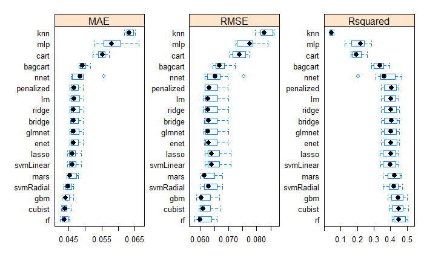

```r
bwplot(results, scales = scales)
```

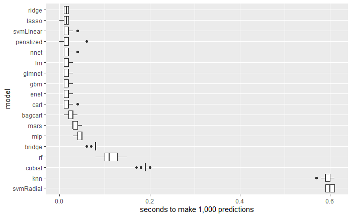

```r
predtimes %>%
  mutate(model = fct_reorder(factor(model), time, median, .desc = T)) %>%
  ggplot(aes(model, time)) +
  geom_boxplot() +
  coord_flip() +
  scale_y_continuous(name = "seconds to make 1,000 predictions")
```

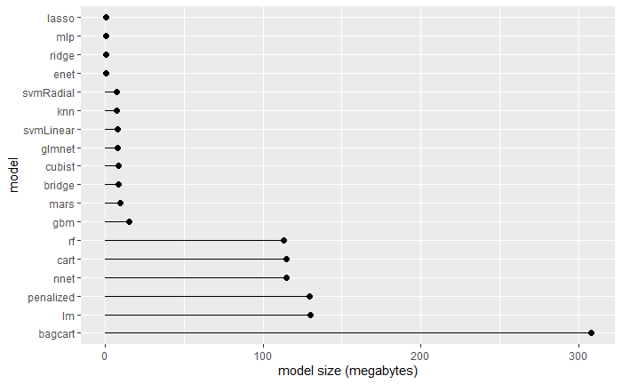

```r
data.frame(model = names(fits), size = sizes) %>%
  mutate(size = size / 1000000,
         model = fct_reorder(factor(model), size, .desc = T)) %>%
  ggplot(aes(model, size)) +
  geom_point(size = 2) +
  geom_segment( aes(x=model, xend=model, y=0, yend=size)) +
  coord_flip() +
  scale_y_continuous(name = "model size (megabytes)")
```

The spot-checking demonstrated that non-linear methods like model trees, random forests, gradient boosting machines, and support vector machines tend to be the most accurate in this case. Regularized parametric models are not quite as accurate, but they tend to be smaller and faster at making predictions.

Of the non-linear models, the gradient boosting machine (gbm) may be the best compromise, offering high accuracy with relatively short prediction times in a smallish package. It also looks like its hyperparameters were not optimized well, and there could be further accuracy gains from revisiting them. Gradient boosting machines tend to be sensitive to their hyperparameters, and the default grid search that was conducted may have been insufficient. The following plot shows that no minimum RMSE was found in the default search. Increasing the number of boosting iterations and the maximum tree depth could lower RMSE values.

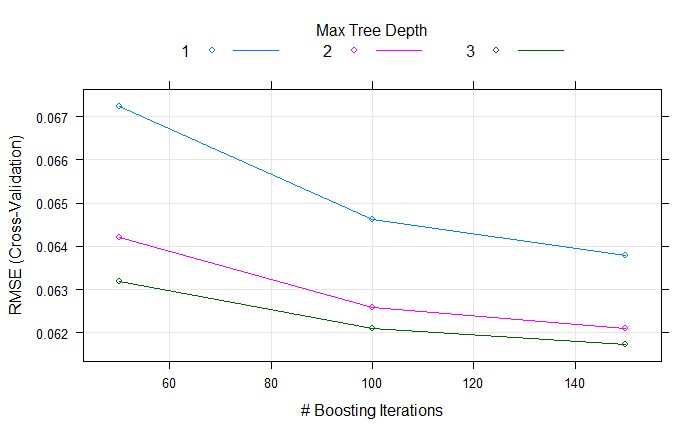

```r
plot(fit.gbm)
```

# Building a Gradient Boosting Machine

In order to optimize its accuracy, the gradient boosting machine was re-tuned following the process outlined by Boehmke and Greenwell in *Hands-On Machine Learning with R* (2020, section 12.3.3). Unfortunately, the tuning depends on the size of the training data, so all of the training data had to be used, which makes the process very slow. Five-fold cross validation was used instead of 10-fold to decrease the training time.

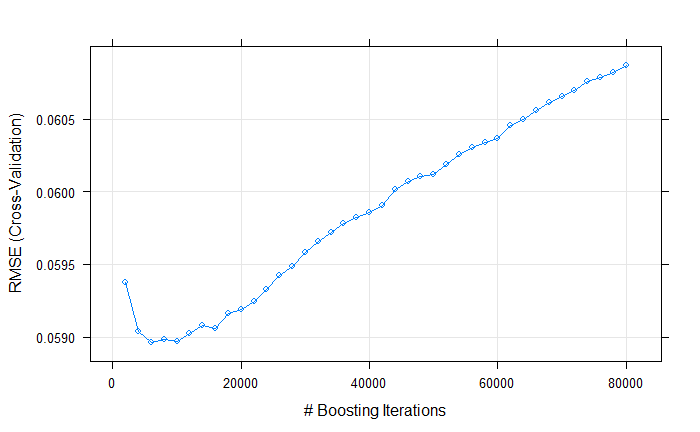

```r
# faster control procedure because this is comp heavy
control2 <- trainControl(method = "cv", number = 5)

# First find best number of boosting iterations (trees) at high learning rate
invisible({capture.output({
  cl <- makePSOCKcluster(10)
  registerDoParallel(cl)

  set.seed(seed)
  fit.gbm1 <- train(dbh_recipe, train, method = 'gbm', metric=metric,
                    trControl=control2, verbose=FALSE,
                    tuneGrid = expand.grid(shrinkage = .5,
                                           n.trees = seq(2000, 80000, by = 2000),
                                           interaction.depth = 3,
                                           n.minobsinnode = 10))

  stopCluster(cl)
})})

plot(fit.gbm1)
```

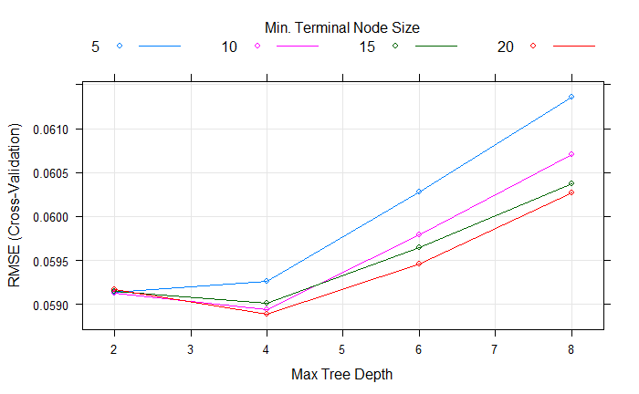

```r
# Then optimize tree-specific parameters
invisible({capture.output({
  cl <- makePSOCKcluster(10)
  registerDoParallel(cl)

  set.seed(seed)
  fit.gbm2 <- train(dbh_recipe, train, method = 'gbm', metric=metric,
                   trControl=control2, verbose=FALSE,
                   tuneGrid = expand.grid(shrinkage = fit.gbm1$bestTune$shrinkage,
                                          n.trees = fit.gbm1$bestTune$n.trees,
                                          interaction.depth = c(2, 4, 6, 8),
                                          n.minobsinnode = c(5, 10, 15, 20)))

  stopCluster(cl)
})})

plot(fit.gbm2)
```

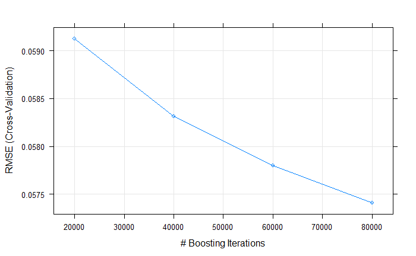

```r
# fit.gbm2 TOOK SEVERAL DAYS. LOWERING LEARNING RATE WILL BE EVEN SLOWER.
# Now can try lower learning rate (shrinkage) and retrain boosting iterations
invisible({capture.output({
  cl <- makePSOCKcluster(10)
  registerDoParallel(cl)

  set.seed(seed)
  fit.gbm3 <-
    train(dbh_recipe, train, method = 'gbm', metric=metric,
          trControl=control2, verbose=FALSE,
          tuneGrid = expand.grid(shrinkage = 0.01,
                                 n.trees = c(20000, 40000, 60000, 80000),
                                 interaction.depth =
                                   fit.gbm2$bestTune$interaction.depth,
                                 n.minobsinnode =
                                   fit.gbm2$bestTune$n.minobsinnode))

  stopCluster(cl)
})})
plot(fit.gbm3)
```

```r
# TAKES SEVERAL DAYS.
# redo b/c didn't reach minimum RMSE
invisible({capture.output({
  cl <- makePSOCKcluster(10)
  registerDoParallel(cl)

  set.seed(seed)
  fit.gbm4 <-
    train(dbh_recipe, train, method = 'gbm', metric=metric,
          trControl=control2, verbose=FALSE,
          tuneGrid = expand.grid(shrinkage = 0.01,
                                 n.trees = c(80000, 100000, 120000, 140000),
                                 interaction.depth =
                                   fit.gbm2$bestTune$interaction.depth,
                                 n.minobsinnode =
                                   fit.gbm2$bestTune$n.minobsinnode))

  stopCluster(cl)
})})
```

[figure not shown]

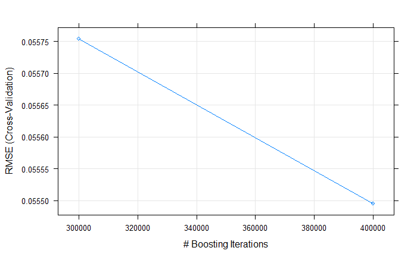

```r
# TAKES SEVERAL DAYS.
# redo b/c didn't reach minimum RMSE
invisible({capture.output({
  library(doParallel)
  cl <- makePSOCKcluster(10)
  registerDoParallel(cl)

  set.seed(seed)
  fit.gbm6 <-
    train(dbh_recipe, train, method = 'gbm', metric=metric,
          trControl=control2, verbose=FALSE,
          tuneGrid = expand.grid(shrinkage = 0.01,
                                 n.trees = c(300000, 400000),
                                 interaction.depth = 4,
                                   #fit.gbm2$bestTune$interaction.depth,
                                 n.minobsinnode = 20))
                                   #fit.gbm2$bestTune$n.minobsinnode))

  stopCluster(cl)
})})
plot(fit.gbm6)
```

```r
# Refit without resampling, to get smaller train object
```

```
There were 30 warnings (use warnings() to see them)
```

```r
invisible({capture.output({
  cl <- makePSOCKcluster(10)
  registerDoParallel(cl)

  set.seed(seed)
  fit.gbm.final <-
    train(dbh_recipe, train, method = 'gbm', metric=metric,
          trControl = trainControl(method = "none"), verbose = FALSE,
          tuneGrid = expand.grid(shrinkage = fit.gbm6$bestTune$shrinkage,
                                 n.trees = fit.gbm6$bestTune$n.trees,
                                 interaction.depth =
                                   fit.gbm6$bestTune$interaction.depth,
                                 n.minobsinnode =
                                   fit.gbm6$bestTune$n.minobsinnode))

  stopCluster(cl)
})})
```

```r
gbmTimes <-
  sapply(1:30, function(k) {
    system.time(predict(fit.gbm.final,
                        newdata = train[sample(1:nrow(train), 1000,
                                               replace = F), ]))[[3]]
  })
```

This final version of the gradient boosting machine achieves a cross-validation RMSE of 0.0555 inches. It uses 1330 megabytes in memory, and takes an average of 7.33 seconds to make one thousand predictions.

```r
saveRDS(fit.gbm.final, file = "dbh-growth-model-gbm.rds")
```

# Lasso Regression as a Slim Alternative

The results above show that the gradient boosting machine did not scale well when applied to the full training set. While the accuracy did improve a fair bit compared to the model trained on a subset of the data, the model’s size and prediction time increased many-fold, creating a model that will be difficult to use. Below, we train a regularized parametric model–quantile regression with lasso penalty–on all of the training data, which we expect will be substantially smaller and faster than the gradient boosting machine, but not as accurate.

```r
invisible({capture.output({
  library(doParallel)
  cl <- makePSOCKcluster(10)
  registerDoParallel(cl)

  set.seed(seed)
  fit.lasso1 <-
    train(dbh_recipe, train, method = 'rqlasso', metric=metric,
          trControl=control, verbose=FALSE,
          tuneGrid = expand.grid(lambda = seq(0, .005, .001)))

  stopCluster(cl)
})})
```

```
Solution may be nonunique
```

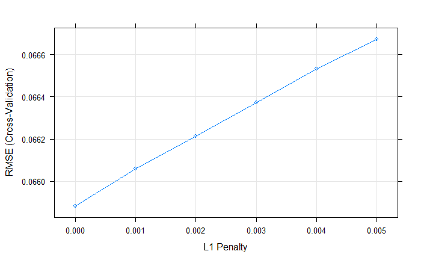

```r
plot(fit.lasso1)
```

```r
# Refit without resampling, to get smaller train object
invisible({capture.output({
  cl <- makePSOCKcluster(10)
  registerDoParallel(cl)

  set.seed(seed)
  fit.lasso.final <-
    train(dbh_recipe, train, method = 'rqlasso', metric=metric,
          trControl = trainControl(method = "none"), verbose = FALSE,
          tuneGrid = expand.grid(lambda = fit.lasso1$bestTune$lambda))

  stopCluster(cl)
})})
```

```
Solution may be nonunique
```

```r
lassoTimes <-
  sapply(1:30, function(k) {
    system.time(predict(fit.lasso.final,
                        newdata = train[sample(1:nrow(train), 1000,
                                               replace = F), ]))[[3]]
  })
```

This final version of quantile regression with lasso achieves a cross-validation RMSE of 0.0659 inches. It uses 339 megabytes in memory, and takes an average of 0.02 seconds to make one thousand predictions.

```r
saveRDS(fit.lasso.final, file = "dbh-growth-model-lasso.rds")
```

As expected, the lasso is much smaller and faster than the gradient boosting machine (3.9 times smaller and 449 times faster), but is not quite as accurate (with an RMSE of 0.0659 inches, compared to the boosting machine’s RMSE of 0.0555 inches).

The disadvantage of the lasso is most likely its inability to account for interactions between predictors. While the gradient boosting machine’s advantage in overall accuracy is relatively small, Maker and Foppert (2021) demonstrated that complex interactions do drive diameter growth trends for trees in less common situations and that nonparametric models like the gradient boosting machine can make much better predictions in those cases. In other words, the gradient boosting machine is probably making a big difference for a minority of trees.

# Compromising With a Support Vector Machine